# Welchen Bezug hat die SNF-Forschung zu den UNO-Nachhaltigkeitszielen?

13.04.2023

**In einer explorativen Analyse hat der SNF untersucht, inwiefern die von ihm geförderten Projekte einen Bezug zu den Zielen der nachhaltigen Entwicklung der Vereinten Nationen haben. Es lassen sich in allen Fachbereichen Bezüge zu den Nachhaltigkeitszielen finden. Nun soll eine Befragung von Forschenden weitere Erkenntnisse liefern.**

Mit den 17 Zielen für nachhaltige Entwicklung der Vereinten Nationen (Sustainable Development Goals, SDGs) soll das menschliche Wohlergehen auf gerechte Weise gefördert werden, sodass niemand zurückgelassen und das natürliche System geschützt wird. Der Forschung kommt dabei eine wichtige Rolle zu: Sie schafft neues Wissen und damit die Grundlage für technologische und soziale Innovation. Damit leistet sie einen Beitrag zum gesellschaftlichen und politischen Diskurs über gemeinsames Handeln und Umdenken.

Mithilfe von zwei Klassifizierungsinstrumenten haben wir eine explorative Analyse durchgeführt, um herauszufinden, inwiefern sich SNF-Projekte auf die Nachhaltigkeitsziele beziehen. Obwohl die Klassifizierungsinstrumente noch nicht vollständig ausgereift sind (siehe Box “Methode und ihre Grenzen”), geben die Resultate erste Einblicke in die vom SNF finanzierte Forschung zu den SDGs.

### Methode und ihre Grenzen

Für diese Analyse haben wir eine Reihe verschiedener, SDG-Klassifizierungsinstrumente geprüft: den SDG-Klassifikator von Dimensions, sowie die Abfragesysteme, die über das öffentlich zugängliche [R-Paket](https://www.r-project.org/about.html) [text2sdg](https://github.com/dwulff/text2sdg#readme) verfügbar sind (Aurora, Elsevier, OSDG, SDSN und SIRIS). Alle diese Instrumente wurden mit den Titeln, Abstracts und Keywords der bewilligten Gesuche gespiesen. Von den Ergebnissen der verschiedenen Instrumente haben wir eine Zufallsstichprobe manuell ausgewertet. Dazu haben wir identifiziert, auf welche SDGs sich die Projekte aus unserer Sicht beziehen und diese Einschätzung mit den von den verschiedenen Instrumenten erzeugten Ergebnissen verglichen. Damit identifizierten wir jene Instrumente, welche die “korrekten” SDGs erkannten und die wenigsten falsch-positiven Ergebnisse lieferten. Als falsch-positiv wird ein Fall bezeichnet, bei dem das Klassifizierungsinstrument einen Bezug zu einem bestimmten SDG identifiziert, der in der Realität nicht besteht. So kamen wir zum Schluss, dass die Instrumente von Dimensions und Elsevier mit den SNF-Daten die besten Resultate erzielen. Im Folgenden werden die Ansätze von Dimensions und Elsevier kurz erläutert.

Dimensions  
Der Dimensions-Klassifikator wurde von Digital Science entwickelt und basiert auf maschinellem Lernen. Mithilfe von [Dimensions](https://www.dimensions.ai/), dem grössten Datensatz an verknüpften Forschungsinformationen (Publikationen, Fördermittel, Forschungsdaten etc.), [erstellte Digital Science aus dem kompletten Satz der 17 SDGs ein Modell aus umfangreichen und spezifischen Suchanfragen](https://digitalscience.figshare.com/ndownloader/files/22574228). Daraus wurden 17 Trainingssätze an Publikationen aus der Dimensions-Datenbank generiert (einer für jedes SDG) und mithilfe von Computerlinguistik ein SDG-Klassifizierungsschema erstellt. Um die Qualität der Trainingssätze zu verbessern, wurde regelmässig überprüft, ob die identifizierten Publikationen der Beschreibung der SDG-Definition entsprechen. Der Dimensions-Klassifikator verwendet in einigen seiner Suchanfragen auch eine Umkreissuche (sogenannte Proximity Search), sodass Sätze, die bestimmte verwandte Wörter enthalten, ebenfalls gefunden werden können.[^1]

Elsevier  
Auch das Data-Science-Team von Elsevier hat [Suchanfragen für SDGs entwickelt](https://elsevier.digitalcommonsdata.com/datasets/87txkw7khs/1). Diese basieren auf [Scopus](https://www.scopus.com/), der bibliographischen Datenbank zu wissenschaftlicher Literatur von Elsevier. Gemeinsam mit Fachexperten wurde eine erste Scopus-Suchanfrage für jedes SDG entwickelt. Dies führte zu einer kuratierten Liste an Publikationen, die einen Bezug zu den SDGs aufweisen. Der Prozess der Verfeinerung der Suchanfragen zu den einzelnen SDGs ist noch nicht abgeschlossen. Elsevier berücksichtigt Kundenfeedback, um die Anzahl der Suchbegriffe zu erhöhen, welche zur Definition der einzelnen SDGs verwendet werden. In einer neueren Version aus den Jahren 2021/2022 wurden die Abfragen zudem durch ein Machine Learning-Modell ergänzt. Für die Analysen in dieser Datengeschichte haben wir die Originalversion von 2019 verwendet. Elsevier berücksichtigt in seinem Klassifizierungsinstrument das SDG 17 (Globale Partnerschaften für die Ziele) nicht. Da wir nur jene Fälle berücksichtigen, in denen beide Klassifizierungsinstrumente das gleiche SDG identifizieren (siehe die Beschreibung des Ansatzes im nächsten Abschnitt), wird dieses SDG in unserer Analyse nicht berücksichtigt.

**Beschränkungen**  
Die automatisierte Identifizierung von Bezügen zu den SDGs mithilfe von Klassifizierungsinstrumenten hat derzeit noch ihre Grenzen. Einerseits werden nicht alle Bezüge zu den SDGs richtig erkannt. Andererseits werden zum Teil Bezüge zu SDGs identifiziert, wo es gar keine gibt. Darüber hinaus begünstigen die Instrumente meist eines oder mehrere der SDGs und überschätzen deren Häufigkeit. Die Qualität der Klassifizierungsinstrumente lässt sich zudem nicht abschliessend beurteilen, da es derzeit nur sehr wenige ausreichend grosse Validierungsdatensätze gibt.[^2]  
Aus diesem Grund haben wir uns für einen vorsichtigen Ansatz entschieden: Wir haben die Resultate der beiden Klassifizierungsinstrumente von Dimensions und Elsevier verglichen und einen SDG-Bezug nur dann als gültig betrachtet, wenn er von beiden Instrumenten erkannt wurde. Diese Methode sollte zu einer angemessenen unteren Grenze führen, mit der im Laufe der Zeit Trends erkannt werden können und das Problem der falsch-positiven Ergebnisse verringert wird. Die Methoden und Ergebnisse sind experimentell. Wir sind trotzdem der Meinung, dass sie interessant sind, da beide Instrumente dasselbe zu messen versuchen, auf ähnlichen Ansätzen beruhen und vergleichbare Ergebnisse liefern.  
In der Zwischenzeit haben die Autoren des R-Pakets text2sdg ein “[Ensemble-Tool](https://arxiv.org/pdf/2301.11353.pdf)” entwickelt, das die einzelnen Klassifizierungsinstrumente zusammenführt. Dieses hat das Potenzial, unseren Ansatz zu übertreffen. Wir begrüssen dies und werden die Entwicklungen in diesem Bereich im Auge behalten.

Vergleich der beiden Klassifizierungsinstrumente - die Abbildung zeigt den Anteil der bewilligten Projekte 2016-2021 mit einem Bezug zu einem SDG

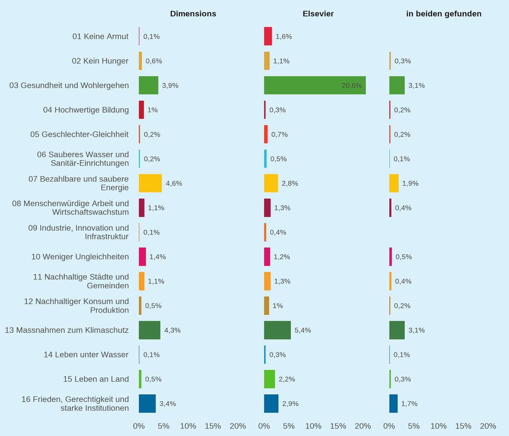

Daten: bewilligte Projekte 2016-2021.

### Alle Fachbereiche forschen zu den Zielen für nachhaltige Entwicklung

Insgesamt fand das kombinierte Klassifizierungssystem bei 1’489 von insgesamt 12’431 Projekten seit 2016 (12%) einen Bezug zu einem oder mehreren SDGs (siehe Box Daten). Diese Projekte wurden mit insgesamt 709 Millionen Franken unterstützt, was 13% der zugesprochenen Mittel entspricht. Ein Bezug zu mehr als einem SDG konnte nur in wenigen Fällen identifiziert werden: In 70 Projekten (0,6%) wurden zwei SDGs identifiziert und lediglich in zwei Projekten wurde ein Bezug zu drei SDGs erkannt.

Bewilligte Projekte 2016-2021, bei denen ein Bezug zu einem oder mehreren SDGs identifiziert wurde (Anteil der Projekte und Anteil des bewilligten Betrags)

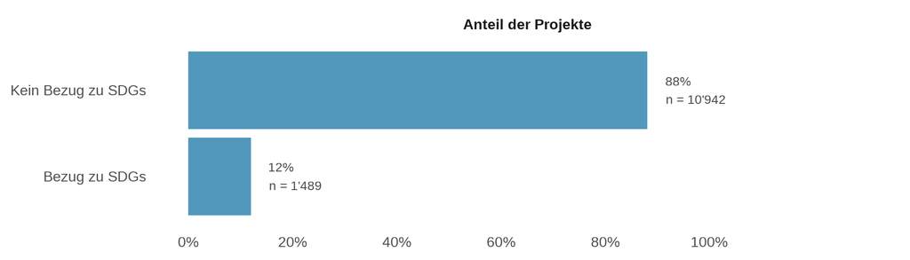

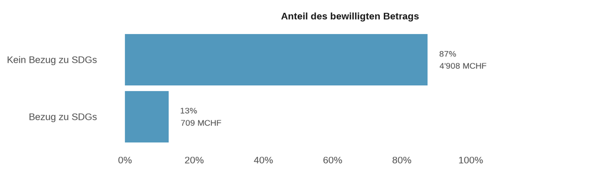

Daten: bewilligte Projekte 2016-2021.

Bewilligte Projekte 2016-2021, bei denen ein Bezug zu einem oder mehreren SDGs identifiziert wurde (Anteil der Projekte und Anteil des bewilligten Betrags)

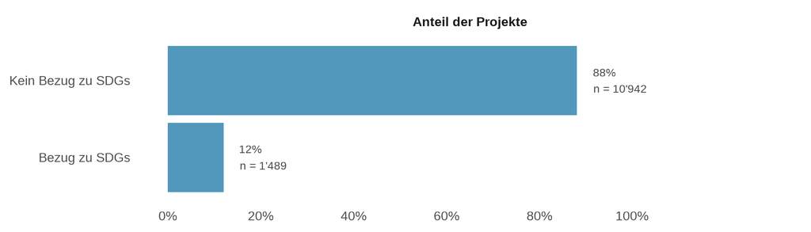

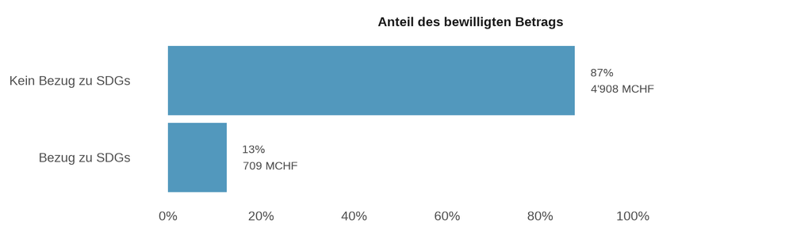

Daten: bewilligte Projekte 2016-2021.

Insgesamt lässt sich seit 2016 ein leichter Aufwärtstrend beobachten: Dem Klassifizierungssystem zufolge gibt es zunehmend mehr Projekte mit einem Bezug zu den SDGs und damit auch mehr finanzielle Mittel, die für die entsprechende Forschung verwendet werden. Zwischen den Fachbereichen (Geistes- und Sozialwissenschaften: GSW, Mathematik, Informatik, Naturwissenschaft und Technik: MINT und Lebenswissenschaften: LW) gibt es keine grossen Unterschiede.

Entwicklung des Anteils der Projekte, bei denen ein Bezug zu einem oder mehreren SDGs identifiziert wurde (Anteil der Projekte und Anteil des bewilligten Betrags)

[interactive chart not shown]

Daten: bewilligte Projekte 2016-2021.

Entwicklung des Anteils der Projekte, bei denen ein Bezug zu einem oder mehreren SDGs identifiziert wurde (Anteil der Projekte und Anteil des bewilligten Betrags)

[interactive chart not shown]

Daten: bewilligte Projekte 2016-2021.

### Am meisten Forschung zu Klimaschutz und Gesundheit

Mit dem Klassifizierungssystem konnten wir feststellen, zu welchen SDGs die SNF-Projekte einen Bezug aufweisen. Am häufigsten wurden Bezüge zu den folgenden sechs SDGs identifiziert:

- SDG 13: Massnahmen zum Klimaschutz (3,1% aller analysierten Projekte)
- SDG 3: Gesundheit und Wohlergehen (3,1 %)
- SDG 7: Bezahlbare und saubere Energie (1,9%)
- SDG 16: Frieden, Gerechtigkeit und starke Institutionen (1,7 %)
- SDG 10: Weniger Ungleichheiten (0,5%)
- SDG 11: Nachhaltige Städte und Gemeinden (0,4%)

Anzahl der von 2016-2021 bewilligten Projekte pro SDG

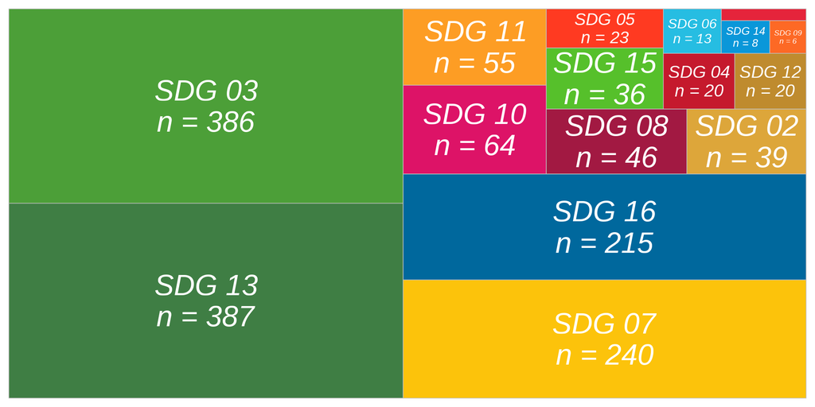

Daten: bewilligte Projekte 2016-2021.

Anzahl der von 2016-2021 bewilligten Projekte pro SDG

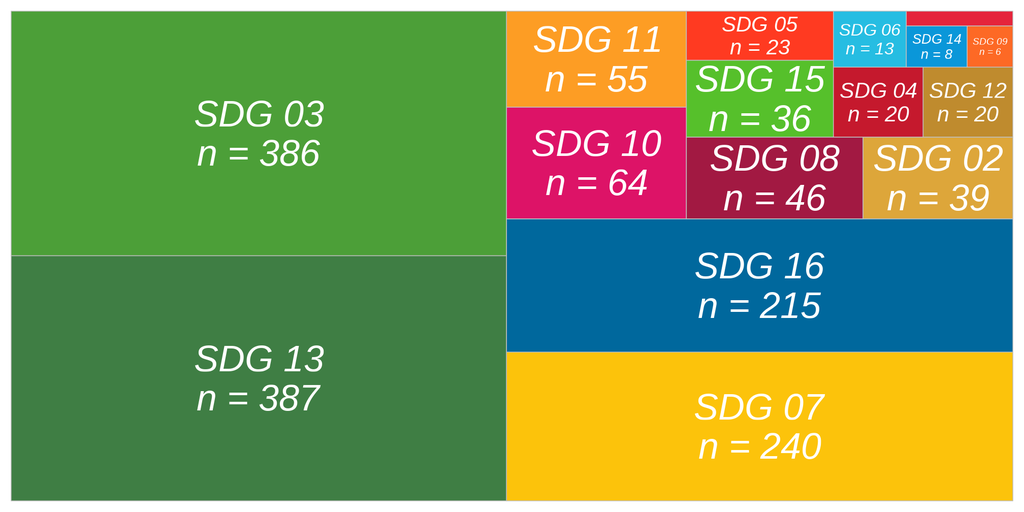

Daten: bewilligte Projekte 2016-2021.

Welche Forschungsbereiche widmen sich diesen SDGs? Bei den Top-3-SDGs scheint es jeweils einen “dominanten” Forschungsbereich zu geben, aber auch die beiden anderen Forschungsbereiche tragen zur Erforschung der jeweiligen Themen bei. Um SDG 16 (Frieden, Gerechtigkeit und starke Institutionen) und SDG 10 (Weniger Ungleichheiten) scheinen sich ziemlich exklusiv die Geistes- und Sozialwissenschaften zu kümmern. SDG 11 (Nachhaltige Städte und Gemeinden) wurde dagegen zu ähnlichen Teilen von den Geistes- und Sozialwissenschaften (GSW) und den Disziplinen im Bereich MINT (Mathematik, Informatik, Naturwissenschaften und Technik) erforscht, wobei die Lebenswissenschaften (LW) ebenfalls eine kleine Rolle spielen.

Beitrag der drei Forschungsbereiche zu den Top-6-SDGs

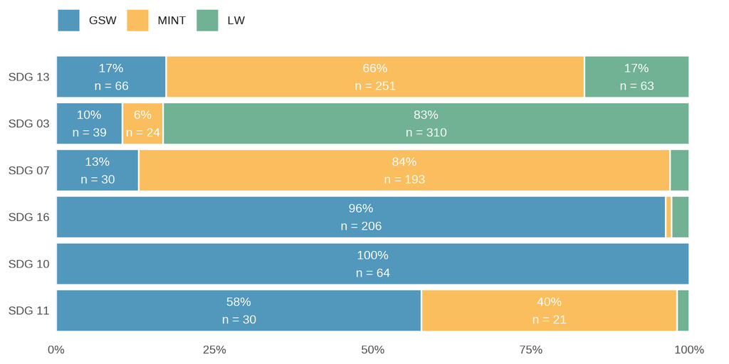

Daten: bewilligte Projekte 2016-2021.

Beitrag der drei Forschungsbereiche zu den Top-6-SDGs

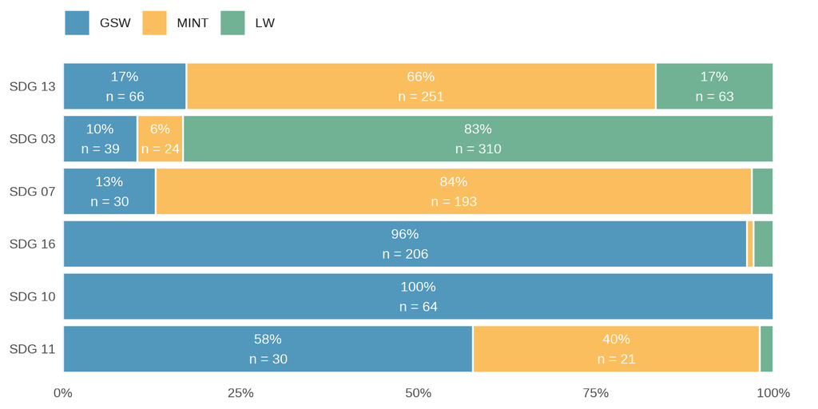

Daten: bewilligte Projekte 2016-2021.

### Forschung zu bezahlbarer und sauberer Energie: mehrere Disziplinen beteiligt

Im Folgenden betrachten wir das sehr aktuelle SDG 7 (Bezahlbare und saubere Energie) genauer. 240 und somit 1,9% aller analysierten Projekte weisen laut dem Klassifizierungssystem einen Bezug zu diesem SDG auf. Damit verbunden sind finanzielle Mittel in der Höhe von 108 Millionen Franken.

In knapp der Hälfte dieser Projekte (44%) sind mehrere Disziplinen beteiligt. Dies ist auch bei den anderen SDGs zu beobachten: An fast der Hälfte der Projekte (47%), für die ein Bezug zu einem SDG identifiziert wurde, sind mehrere Disziplinen beteiligt. Der Anteil derartiger Projekte an allen vom SNF geförderten Projekte beträgt dagegen nur 41%. Diese Erkenntnis stärkt die [These](https://www.nature.com/articles/525315a), wonach sich disziplinenübergreifende Zusammenarbeit zur Behandlung globaler Herausforderungen besonders gut eignet: Komplexe Fragestellungen erfordern Zusammenarbeit, Konsensbildung, Validierung, gegenseitige Befruchtung von Ideen und effektive Kommunikation über wissenschaftliche Disziplinen hinweg.

Anzahl beteiligter Disziplinen in Projekten, bei denen ein Bezug zu SDG 7 (Bezahlbare und saubere Energie) identifiziert wurde

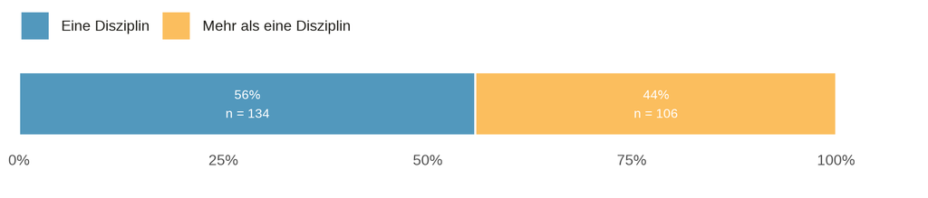

Daten: bewilligte Projekte 2016-2021 mit Bezug zu SDG 7.

Anzahl beteiligter Disziplinen in Projekten, bei denen ein Bezug zu SDG 7 (Bezahlbare und saubere Energie) identifiziert wurde

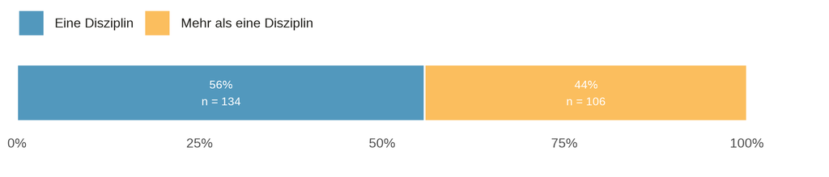

Daten: bewilligte Projekte 2016-2021 mit Bezug zu SDG 7.

In den Projekten mit einem Bezug zum SDG 7 finden wir am häufigsten die Kombination folgender Fachgebiete:

- Chemie und Ingenieurwissenschaften (46 Projekte, 43%)
- Physik und Ingenieurwissenschaften (15 Projekte, 14%)
- Chemie und Physik (13 Projekte, 12%)

Dabei arbeiten auch häufig zwei oder mehr Gesuchstellerinnen und Gesuchsteller zusammen. So sind 23% der Projekte im Zusammenhang mit SDG 7 kollaborativ. Diesen Anteil finden wir über alle Projekte mit einem SDG-Bezug hinweg (23%). Über alle untersuchten Projekte hinweg liegt der Anteil kollaborativer Projekte hingegen bei nur 19%.

Grad der Zusammenarbeit in Projekten, bei denen ein Bezug zu SDG 7 (Bezahlbare und saubere Energie) identifiziert wurde

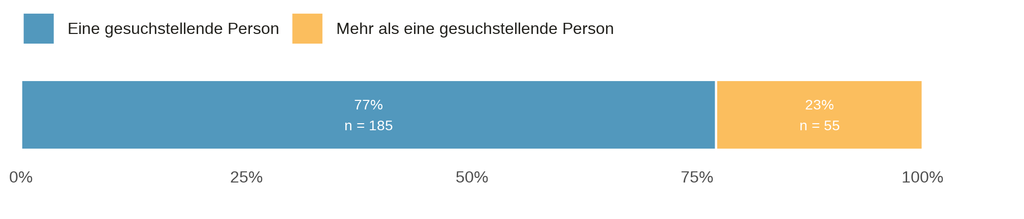

Daten: bewilligte Projekte 2016-2021 mit Bezug zu SDG 7.

Grad der Zusammenarbeit in Projekten, bei denen ein Bezug zu SDG 7 (Bezahlbare und saubere Energie) identifiziert wurde

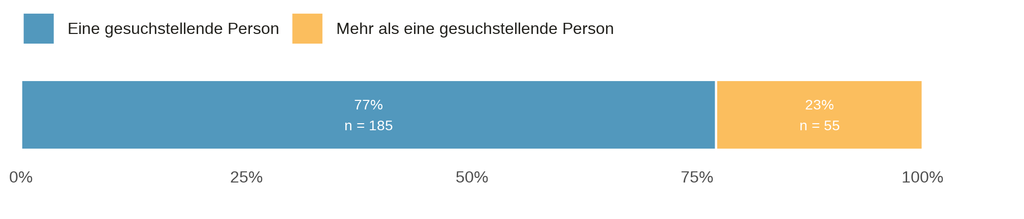

Daten: bewilligte Projekte 2016-2021 mit Bezug zu SDG 7.

An den 55 kollaborativen SDG-7-Projekten sind insgesamt 152 Gesuchstellerinnen und Gesuchsteller beteiligt. Am häufigsten finden Zusammenarbeiten zwischen Institutionen in der Schweiz mit solchen aus dem Ausland statt. Eine solche internationale Zusammenarbeit finden wir in 28 Projekten.

### 2023: Lancierung einer Befragung zu SDGs

Wie weiter oben erwähnt, sind die verwendeten Klassifizierungsinstrumente noch nicht vollständig ausgereift, sodass wir auf dieser Basis noch nicht abschliessend beurteilen können, wie viele Projekte tatsächlich einen Bezug zu den SDGs haben. Um diesbezüglich einen besseren und vertiefteren Einblick zu erhalten, startet der SNF 2023 eine Befragung von Projektleitenden zum konkreten Beitrag ihrer Projekte zu den SDGs. Damit verschaffen wir uns einen systematischen Überblick und sehen, wo das bestehende Wissen zur nachhaltigen Entwicklung Lücken aufweist. So können wir mit geeigneten Initiativen Forschungsprojekte anstossen, um diese Lücken zu füllen und so einen Beitrag zum Erreichen der SDGs leisten.

### Daten

Für diese Datengeschichte haben wir die Daten der bewilligten Projekte mit Förderentscheiden zwischen 2016 und 2021 verwendet. Ausgeschlossen sind alle Projekte der Wissenschaftskommunikation – diese Kategorie umfasst Scientific Exchanges, Agora, Open-Access-Gebühren und Publikationsbeiträge. Aufgrund ihrer unterschiedlichen Struktur wurden auch die Nationalen Forschungsschwerpunkte (NFS) nicht berücksichtigt. Insgesamt wurden 12‘431 Projekte analysiert.

**Projekte mit Beteiligung mehrerer Disziplinen** identifizierten wir anhand der entsprechenden Angaben der Gesuchstellenden (Haupt- und Nebendisziplinen, siehe [Disziplinenliste des SNF](https://www.snf.ch/SiteCollectionDocuments/allg_disziplinenliste.pdf)). Die SNF-Disziplinenliste besteht aus drei Ebenen: Übergeordnet sind die drei Forschungsbereiche Geistes- und Sozialwissenschaften (GSW), Mathematik, Informatik, Naturwissenschaften und Technik (MINT) und die Lebenswissenschaften (LW). Die zweite Ebene verfeinert diese Forschungsbereiche, und die Disziplinen der Ebene drei sind noch feinkörniger. Sind in einem Projekt mindestens zwei verschiedene Disziplinen der zweiten Ebene aufgeführt, definieren wir es als Projekt mit Beteiligung mehrerer Disziplinen.

An **kollaborativen Projekten** sind mindestens zwei Gesuchstellende beteiligt. Dazu gehören eine korrespondierende gesuchstellende Person und mindestens eine weitere gesuchstellende Person.

**Weiterführende Links**

[Nachhaltige Entwicklung](https://www.snf.ch/de/3DEoAgSx2yMXZaAX/thema/nachhaltige-entwicklung)

Daten, Text und Code zu dieser Datengeschichte sind [auf Github verfügbar](https://github.com/snsf-data/datastory_snf_research_and_sdgs) und [auf Zenodo archiviert](https://doi.org/10.46446/datastory.snf-research-and-sdgs).  
DOI: 10.46446/datastory.snf-research-and-sdgs

[^1]: Wastl J, Hook DW, Fane B, Draux H, Porter SJ. 2020. Contextualizing Sustainable Development Research. Using Dimensions to explore the global landscape of research on Sustainable Development Goals. Digital Science. Report. https://doi.org/10.6084/m9.figshare.12200081.v2
[^2]: Wulff DU, Meier DS, Mata R. 2023. Using novel data and ensemble models to improve automated labeling of Sustainable Development Goals. Preprint: https://arxiv.org/pdf/2301.11353.pdf